# Predição de votação de candidatos à Câmara Federal de Deputados

Ivyna Santino

4 de novembro de 2018

### Descrição do problema:

O objetivo desse checkpoint é construir modelos de regressão para a predição de votação de candidatos à Câmara Federal de Deputados.

### Iniciando

#### Importando dados

Antes de tudo, iremos importar os dados de treino e teste:

```r
train = importa_eleicao("train.csv")
test = importa_eleicao("test.csv")
```

#### Preparando dataframe:

Nessa parte inicial, optei por retirar algumas variáveis contidas na base de dados afim de faciltar a criação dos modelos posteriormente.

```r
train <- train %>%
  select(-cargo,
         -sequencial_candidato,
         -ocupacao,
         -uf,
         -nome)
```

### Criação dos modelos

- Modelo de regressão Ridge
- Modelo de regressão Lasso
- Modelo KNN

```r
modelo_ridge <- train(votos ~ .,
                     data = train,
                     method = "ridge")
modelo_lasso <- train(votos ~ .,
                     data = train,
                     method = "lasso")
modelo_knn <- train(votos ~ .,
                     data = train,
                     method = "knn")
```

```r
modelo_ridge
```

```
Ridge Regression

7476 samples
  18 predictors

No pre-processing
Resampling: Bootstrapped (25 reps)
Summary of sample sizes: 7476, 7476, 7476, 7476, 7476, 7476, ...
Resampling results across tuning parameters:

  lambda  RMSE      Rsquared   MAE
  0e+00   56515.38  0.3442496  16932.85
  1e-04   37477.05  0.3962081  16466.81
  1e-01   38050.98  0.3902056  16440.98

RMSE was used to select the optimal model using the smallest value.
The final value used for the model was lambda = 1e-04.
```

```r
modelo_lasso
```

```
The lasso

7476 samples
  18 predictors

No pre-processing
Resampling: Bootstrapped (25 reps)
Summary of sample sizes: 7476, 7476, 7476, 7476, 7476, 7476, ...
Resampling results across tuning parameters:

  fraction  RMSE      Rsquared   MAE
  0.1       41296.23  0.3360462  17264.30
  0.5       58228.20  0.2717016  16931.75
  0.9       78294.50  0.2600462  17345.89

RMSE was used to select the optimal model using the smallest value.
The final value used for the model was fraction = 0.1.
```

```r
modelo_knn
```

```
k-Nearest Neighbors

7476 samples
  18 predictors

No pre-processing
Resampling: Bootstrapped (25 reps)
Summary of sample sizes: 7476, 7476, 7476, 7476, 7476, 7476, ...
Resampling results across tuning parameters:

  k  RMSE      Rsquared   MAE
  5  37343.24  0.4268117  13959.22
  7  35736.20  0.4583032  13460.61
  9  34970.26  0.4753359  13182.20

RMSE was used to select the optimal model using the smallest value.
The final value used for the model was k = 9.
```

### Comparação dos modelos em termos do erro RMSE

Para ficar mais fácil a observação dos valores mínimos, é mais intuitivo observar da seguinte forma:

```r
min(modelo_ridge$results$RMSE)
```

```
[1] 37477.05
```

```r
min(modelo_lasso$results$RMSE)
```

```
[1] 41296.23
```

```r
min(modelo_knn$results$RMSE)
```

```
[1] 34970.26
```

Dessa forma, podemos observar o modelo feito com o knn teve o menor resultado para o RMSE e o mais alto foi o método feito pelo lasso.

### Importância das variáveis em modelos de regressão Ridge e Lasso

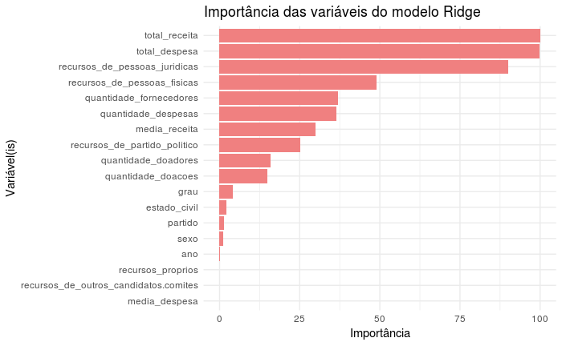

```r
ggplot(varImp(modelo_ridge)) +
geom_col(fill = "#F08080") +
labs(title = "Importância das variáveis do modelo Ridge",
     y = "Importância",
     x = "Variável(is)")
```

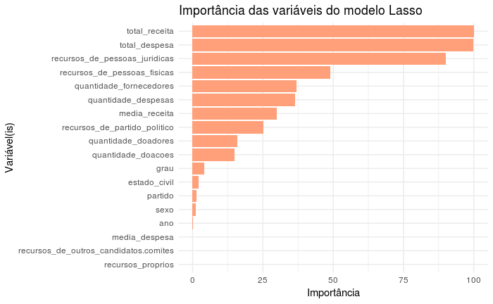

```r
ggplot(varImp(modelo_lasso)) +
geom_col(fill = "#FFA07A") +
labs(title = "Importância das variáveis do modelo Lasso",
     y = "Importância",
     x = "Variável(is)")
```

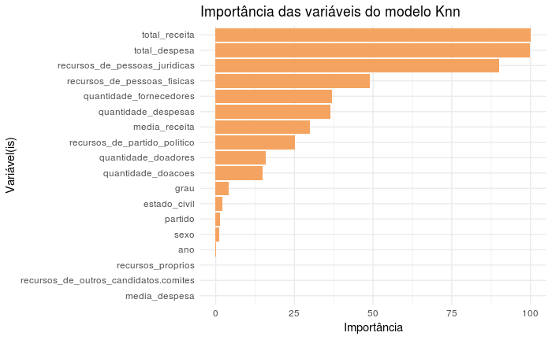

```r
ggplot(varImp(modelo_knn)) +
geom_col(fill = "#F4A460") +
labs(title = "Importância das variáveis do modelo Knn",
     y = "Importância",
     x = "Variável(is)")
```

```r
NA
```

A partir das visualizações acima, podemos observar que as seguintes variáveis tem um menor nível de importância para o modelo:

- media_despesa
- recursos_de_outros_candidatos.comites
- recursos_proprios

Obs.: o critério de seleção das variáveis menos importantes se deu pelo nível de importância zero.

Dessa forma, utilizei total_receita, total_despesa, recursos_de_pessoas_juridicas, recursos_de_pessoas_fisicas, quantidade_fornecedores, quantidade_despesas, media_receita, recursos_de_partido_politico, quantidade_doadores, quantidade_doacoes, grau, estado_civil, partido, sexo e ano, deixando o modelo mais enxuto e possibilitando a construção de um novo modelo com menos variáveis e mais representativo.

### Formando novo modelo

Para formar um novo modelo, selecionei as variáveis com maior nível de importância de acordo com os resultados vistos acima e criei um novo dataframe.

### Retreinando o melhor modelo

```r
modelo_select_knn <- train(votos ~ .,
                     data = modelo_select,
                     method = "knn")
```

```r
modelo_select_knn
```

```
k-Nearest Neighbors

7476 samples
  15 predictors

No pre-processing
Resampling: Bootstrapped (25 reps)
Summary of sample sizes: 7476, 7476, 7476, 7476, 7476, 7476, ...
Resampling results across tuning parameters:

  k  RMSE      Rsquared   MAE
  5  38213.30  0.4022570  13991.09
  7  36659.50  0.4314683  13531.68
  9  35687.62  0.4533011  13212.95

RMSE was used to select the optimal model using the smallest value.
The final value used for the model was k = 9.
```

Da mesma forma do modelo anterior, é mais intuitivo observar o valor mínimo do RMSE abaixo:

```r
min(modelo_select_knn$results$RMSE)
```

```
[1] 35687.62
```

Podemos observar dessa vez que o valor do RMSE aumentou em comparação ao modelo com todas as variáveis.

### Use esse último modelo treinado para prever os dados de teste disponíveis no challenge que criamos na plataforma Kaggle

```r
submissao <- test %>%
  select(sequencial_candidato)
test <- test %>%
  select(-cargo,
         -sequencial_candidato,
         -ocupacao,
         -uf,
         -nome)
```

```r
predicao <- predict(modelo_select_knn, test)
submissao$votos <- predicao
submissao <- submissao %>%
  select(ID = sequencial_candidato,
         votos = votos)
```

```r
write.csv(x = submissao,
          file = "../data/sample_submission.csv",
          row.names = FALSE)
```